# gaussian_fit()

## Introduction

Peak procedure trials are a common method used in experimental behavior analysis to study timing behavior. In these trials, subjects are typically trained to respond after a specific interval, usually measured in seconds. The timing of these responses is then analyzed to understand the underlying mechanisms of temporal processing.

One common approach to analyzing peak procedure data is by fitting a Gaussian plus linear function to the observed responses, as demonstrated by [Buhusi, C. V., Perera, D., & Meck, W. H. (2005)](https://psycnet.apa.org/doi/10.1037/0097-7403.31.1.18). This function captures the characteristic shape of response distributions observed in peak procedure trials.

Here we introduce the `gaussian_fit()` function, which utilizes the nonlinear least squares method (Levenberg–Marquardt) implemented in the `minpack.lm` package to adjust a Gaussian + linear function to experimental timing data. The function returns a list of estimated parameters that best fit the curve to the experimental data.

Such parameters correspond to the following model:
$$Rate(t)=ae^\frac{-(t-t_0)^2}{2b^2}+c(t-t_0)+d$$
Where $Rate(t)$ is the response rate at time $t$; $t_0$ represents the peak response time of the function, $b$ is the amplitude of the Gaussian distribution, and the sum of peak parameters $a$ and $d$ pertains to the response rate.

The `gaussian_fit()` function takes the following parameters:

- `responses` numeric vector for the response rate at each time bin.
- `time` numeric vector for the time bins.
- `par` a list of initial parameters for the gaussian + linear function which will be used to start searching for the optimized values (this is optional, the default values are *a* = 0.1, *d* = 0.1, *t0* = 18, *b* = 10, *c* = 1).
- `max.iter` the maximum number of iterations for the adjusting process.

## Example

First let’s load an example data set from an experimental session and assign it to the response and time parameters:

```r
data('gauss_example')
t_example <- data$Bin
res_example <- data$Response_Average
```

Now let’s call the `gaussian_fit()` function to obtain the list of optimized parameters to fit the model:

```r
par_est <- gaussian_fit(responses = res_example, time = t_example, max.iter = 1000)

print(par_est, digits = 3)
```

```
##       a       d      t0       b       c
##  3.5766 -1.0737 19.4767 18.6871  0.0334
```

*Note that we omitted the* `par` *parameter.*

Now let’s create the time and response data points for the fitted curve:

```r
g_plus_lin <- function(par, tiempo) {
  par$a * exp(-0.5 * ((tiempo - par$t0) / par$b)**2) + par$c * (tiempo - par$t0) + par$d
} # The gaussian + linear model.

time_points <- seq(0, 90, 0.1) # In this example we used a FI30 program so the trail lenght is 90s.
y_fit <- g_plus_lin(par_est |> as.list(), time_points) #This function create the data points using the estimated parameters applied to a gaussian + linear function.
```

Finally let’s plot the results:

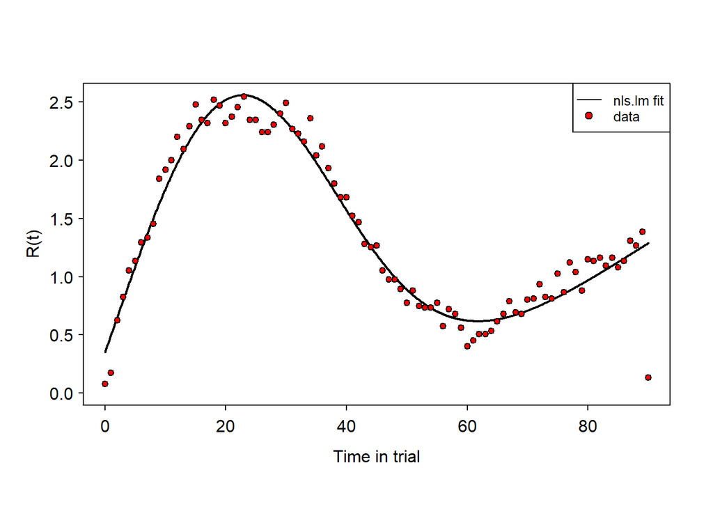